# M5 Competition Pipeline - Forecasting Sales of Walmart Products

Author: Anil Gurbuz

Date: 27 JUN 2020

# Introduction

## Acknowledgement

I want to start with thanks to winning team of "Favorita Groceries Sales Competition" for sharing their interesting solution which achieved highest predictive performance only using the last 3 months of the data with a very small training time and let me learn a lot from. This notebook is a adaptation of that approach to M5 forecasting competition.

## What is interesting about this approach?

Instead of representing sales of each day as a row in the training data as in most of the public kernels, each series are represented as a row --similar to the given format by the competition organisers--. This is particularly advantagous for code efficiency as we don't need to use pandas "groupby" which is horribly slow especially when the number of groups are high as in this data -- 30490 groups --.

I will be creating 200+ features for the purpose of this first version of the notebook. They are mostly running statistics on sales, calendar, intermittent demand and price related features -- some are adjusted versions of features for this approach from other public kernels --.

All feature creations, and training of 28 models finishes around 20mins.

## What about predictive performance?

I have created my pipeline with regualar approach and also developed this one to discover how this interesting modelling technique works. I can say that in terms of the final WRMSSE score, almost always the regular approach performed better even though it was based on only some basic features relative to this approach. For the best --that I managed to achieve-- of each approach were not so different. My best 28days model with regular approach gave LB 0.61XX whereas with this approach, I managed to get LB 0.63XX none of them use recursive features or magic multipliers. I used quite a lot of complex features that I prefered to keep it to myself until the end of the competition though I can say that they are mainly targeting to capture SNAP-sales interactions.

In terms of the performance, this version of the notebook is intended to be a starter code for those of you that are willing to explore this approach. I can easily say that it taught me a lot about how wide range of ways are possible to model a problem. I will try to explain how this model works in more detail in the upcoming steps.

## How this model works?

[figure not shown]

For each series we look back from some certain points in time -- with one week gaps in between-- and derive features to describe the behaviour of the series up until that point in time.

### This is actually the main difference with the regular approach. We are deriving features to explain the characteristics of the entire series up until that point in time instead of deriving features that are describing the characteristics of one single day.

Above image is showing the points in time that the features are generated. Gaps between are one week which aims to capture weekly cycle in the data. Arrows are looking back to represent that the features at that point are created by looking back in time.

Once we have our features generated, we create 28 models which learns the relationship between these features of a series and the next 1,2,3....28 days sales. Each of these models are designed to learn the relationship between the same derived features and different forecasting horizons so for each training example we have 28 different labels.

## What are potential improvements?

- Creating linear regression models to capture the trend of the series -- because the decision trees are not able to extrapolate so struggle with trend -- and adding predictions as features would definitely help as they helped to regular approach.
- Trying different custom loss functions.
- Predicting higher levels and reconciling to lower levels of forecast (Top-down approach).Thanks @chrisrichardmiles for suggesting that.
- This notebook that I shared [here](https://www.kaggle.com/anlgrbz/clustering-with-intermittent-demand-related-featrs) clusters the examples according to their intermittent demand related characteristics. I used this clusters to train models seperately.

## What is the main advantage of using this approach?

#### It is a day-by-day model -- consists of 28 seperate models-- so we have the flexibility to modify models for different days. At the same time, training is so fast that we can quickly try different ideas and see how the model performance reacts to it. I think this flexibility and pace is a rare and valuable combination by looking at the public kernels.

Ability to quickly try ideas is critical in here because most of people are struggling to create a trust worthy CV strategy --including me-- so we can search for correlation of CV and LB much more quickly. Also, if you have an existing CV that requires hours of time and you got sick of it, you may prefer to pivot your approach to this one.

## Notes

- I calculated the WRMSSE weights and constants in my local computer and loaded it to the kernel using a pickle file so the additional .pkl files are just these weights.
- Even though code works quite fast, I created some check point like save_obj(), load_obj() functions and commented them out for those of you that want to avoid each time running the pre-processing and feature engineering parts of the code.
- I mainly created 4 datasets in pre-processing to derive the features from. snap_df is not used in this notebook but It is useful to develop further features.

```python
import wrmsse_utility as w
from datetime import date, timedelta
import gc
import pandas as pd
import numpy as np
from sklearn.preprocessing import LabelEncoder
import pickle
from tqdm import tqdm
import lightgbm as lgb
import random
import warnings
warnings.filterwarnings('ignore')

def save_obj(obj, name):
    with open(  name + '.pkl', 'wb') as f:
        pickle.dump(obj, f, pickle.HIGHEST_PROTOCOL)

# Define functions for loading pickle files during upcoming steps.
def load_weights2(name):
    with open('../input/weights2/' + name + '.pkl', 'rb') as f:
        return pickle.load(f)

def load_avoid_spike(name):
    with open('../input/avoid-spike/' + name + '.pkl', 'rb') as f:
        return pickle.load(f)

def load_from_scratch(name):
    with open('../input/from-scratch/' + name + '.pkl', 'rb') as f:
        return pickle.load(f)

def load_clusters(name):
    with open('../input/clusters/' + name + '.pkl', 'rb') as f:
        return pickle.load(f)
```

## Data Preprocessing

```python
train_df = pd.read_csv("../input/m5-forecasting-accuracy/sales_train_evaluation.csv")
calendar = pd.read_csv("../input/m5-forecasting-accuracy/calendar.csv")
price = pd.read_csv("../input/m5-forecasting-accuracy/sell_prices.csv")
submission = pd.read_csv("../input/m5-forecasting-accuracy/sample_submission.csv")

category_cols = ['item_id', 'dept_id', 'cat_id', 'store_id', 'state_id']
no_id_id_columns = ['item_id', 'store_id', 'cat_id', 'dept_id', 'state_id']
id_cols = ["id"] + category_cols
id_df = train_df[id_cols]  # id_df not encoded
print("running")
# Label Encoding of categorical variables
mapper = {}
for col in category_cols:
    le = LabelEncoder()
    mapper[col] = dict(zip(le.fit_transform(train_df[col]), train_df[col]))
    train_df[col] = le.fit_transform(train_df[col])

multi_indexes = train_df.set_index(category_cols).index  # multi_indexes are encoded
INDEX_ITEM = multi_indexes.get_level_values("item_id")
INDEX_DEPT = multi_indexes.get_level_values("dept_id")
INDEX_STORE = multi_indexes.get_level_values("store_id")


# Create ordered_ids_and_weights -- Weights are pre-calculated
agg_level_to_denominator = load_weights2("agg_to_denominator2")
agg_level_to_weight = load_weights2("agg_to_weight2")

final_multiplier = (agg_level_to_weight[11]) / agg_level_to_denominator[11]
final_multiplier = final_multiplier.reset_index()
final_multiplier["id"] = final_multiplier["item_id"] + "_" + final_multiplier["store_id"] + "_evaluation"
final_multiplier.drop(["item_id", "store_id"], axis=1, inplace=True)
del agg_level_to_weight, agg_level_to_denominator
gc.collect()

ordered_ids_and_weights = pd.merge(id_df, final_multiplier, on=["id"], how="left")
ordered_ids_and_weights = ordered_ids_and_weights[[0]]
ordered_ids_and_weights.index = multi_indexes
ordered_ids_and_weights = ordered_ids_and_weights.reset_index()
ordered_ids_and_weights = ordered_ids_and_weights.rename({0: "weights"}, axis=1)


# Trainset set column names
train_df.set_index(keys=id_cols, inplace=True)
start_date = date(2011, 1, 29)
train_df.columns = pd.date_range(start_date, freq="D", periods=1941)
train_df.reset_index(inplace=True)


# Calendar
calendar["date"] = pd.to_datetime(calendar.date)

# Preprocess price -- represent dates as columns
price_df = pd.merge(price, id_df, how="left", on=["item_id", "store_id"])

tmp = calendar[["wm_yr_wk", "date"]]
tmp = tmp.groupby("wm_yr_wk").agg(list).reset_index()
price_df = pd.merge(price_df, tmp, how="left", on="wm_yr_wk")
price_df = price_df.explode("date")
price_df.drop(["wm_yr_wk"], axis=1, inplace=True)

price_df = price_df.set_index(id_cols + ["date"])
price_df = price_df[["sell_price"]].unstack()
price_df.columns = price_df.columns.droplevel()
price_df.reset_index(inplace=True)


# Preprocess Calendar and SNAP
tmp = calendar[["date", "event_name_1"]]


tmp2 = tmp.dropna(axis=0)
calendar_df = pd.DataFrame(columns=pd.date_range(start_date, freq="D", periods=1913 + 56),
                           index=tmp2.event_name_1.unique())
tmp3 = tmp2.groupby("event_name_1").agg(list).reset_index()
a = zip(tmp3["event_name_1"], tmp3["date"])
for row, col in a: calendar_df.loc[row, col] = 1

snap_ca = pd.DataFrame(index=["CA"], columns=pd.date_range(start_date, freq="D", periods=1913 + 56))
snap_tx = pd.DataFrame(index=["TX"], columns=pd.date_range(start_date, freq="D", periods=1913 + 56))
snap_wa = pd.DataFrame(index=["WI"], columns=pd.date_range(start_date, freq="D", periods=1913 + 56))

snap_ca.loc["CA", :] = calendar["snap_CA"].values
snap_tx.loc["TX", :] = calendar["snap_TX"].values
snap_wa.loc["WI", :] = calendar["snap_WI"].values
snap_df = pd.concat([snap_ca, snap_tx, snap_wa])

calendar_df = calendar_df.fillna(0)

#Remove Repeating records in Calendar and create seperate series for NBA and Ramadan
calendar_df = calendar_df.loc[calendar_df.index!= "LentWeek2",]
calendar_df.iloc[-1,:] = calendar_df.iloc[6,:].values + calendar_df.iloc[-1,:].values # Easter Fix
calendar_df.iloc[-6,:] = calendar_df.iloc[-3,:].values + calendar_df.iloc[-6,:].values # Christmas Fix

NBA = (calendar_df.iloc[11,:].values + calendar_df.iloc[12,:].values).cumsum() %2
NBA = pd.Series(NBA, index=calendar_df.columns)
RAMADAN = (calendar_df.iloc[15,:].values + calendar_df.iloc[16,:].values).cumsum() %2
RAMADAN = pd.Series(RAMADAN, index=calendar_df.columns)

calendar_df = calendar_df.loc[~calendar_df.index.isin(["OrthodoxEaster","OrthodoxChristmas","NBAFinalsStart",\
                                                       "NBAFinalsEnd","Ramadan starts","Eid al-Fitr"]),]

event_mapper = dict(zip(list(range(1,24)),list(calendar_df.index)))
calendar_df = ((np.arange(1,24) * calendar_df.T).T).sum()


mapper_back_state = {v: k for k, v in mapper["state_id"].items()}
snap_df.index = snap_df.index.map(mapper_back_state)


del snap_ca, snap_tx, snap_wa, tmp, tmp2, tmp3, calendar, price, mapper_back_state

print("Dataframes are ready...")
```

```
running
Dataframes are ready...
```

## Feature Engineering

```python
# Select only the part of the data that will be used in training and feature engineering
def sample_from_train(train_df, start, end):
    return train_df[ id_cols + list(pd.date_range(start, end))]

# Select the data between minus days before the date_from and date_from
def get_timespan(df, date_from, minus, periods, freq="D"):
    return df[pd.date_range(date_from - timedelta(days=minus), periods=periods, freq=freq)]


# Create sales related features
def fe(df, date_from, get_label=True, name_prefix=None):
    X = dict()

    # Windows size 3,7,30,180 -- Selected by intuition and trail
    for i in [3, 7, 30, 180]:
        tmp = get_timespan(df, date_from, i, i)
        X['diff_%s_mean' % i] = tmp.diff(axis=1).mean(axis=1).values
        X['mean_%s_decay' % i] = (tmp * np.power(0.9, np.arange(i)[::-1])).sum(axis=1).values
        X['mean_%s' % i] = tmp.mean(axis=1).values
        X['median_%s' % i] = tmp.median(axis=1).values
        X['min_%s' % i] = tmp.min(axis=1).values
        X['max_%s' % i] = tmp.max(axis=1).values
        X['std_%s' % i] = tmp.std(axis=1).values

    # Windows size 3,7,15,30 -- Selected by intuition and trail
    for i in [3, 7, 15, 30]:
        tmp = get_timespan(df, date_from + timedelta(days=-7), i, i)
        X['diff_%s_mean_2' % i] = tmp.diff(axis=1).mean(axis=1).values
        X['mean_%s_decay_2' % i] = (tmp * np.power(0.9, np.arange(i)[::-1])).sum(axis=1).values
        X['mean_%s_2' % i] = tmp.mean(axis=1).values
        X['median_%s_2' % i] = tmp.median(axis=1).values
        X['min_%s_2' % i] = tmp.min(axis=1).values
        X['max_%s_2' % i] = tmp.max(axis=1).values
        X['std_%s_2' % i] = tmp.std(axis=1).values

    # Windows size 3,7,13,30,180 -- Selected by intuition and trail
    for i in [3, 7, 14, 30, 180]:
        tmp = get_timespan(df, date_from, i, i)
        X['has_sales_days_in_last_%s' % i] = (tmp > 0).sum(axis=1).values
        X['last_has_sales_day_in_last_%s' % i] = i - ((tmp > 0) * np.arange(i)).max(axis=1).values
        X['first_has_sales_day_in_last_%s' % i] = ((tmp > 0) * np.arange(i, 0, -1)).max(axis=1).values
        X['Number_of_days_to_max_sales_in_last_%s' % i] = (pd.to_datetime(date_from) - pd.to_datetime(
            get_timespan(df, date_from, i, i).idxmax(axis=1).values)).days.values
        X['Number_of_days_to_min_sales_in_last_%s' % i] = (pd.to_datetime(date_from) - pd.to_datetime(
            get_timespan(df, date_from, i, i).idxmin(axis=1).values)).days.values

    # Lag features of last 7 days
    for i in range(1, 8):
        X["lag_%s" % i] = get_timespan(df, date_from, i, 1).values.ravel()

    # Weekday avg. of 4,8,13,26,52 weeks windows
    for i in range(7):
        X["mean_4_dow_%s" % i] = get_timespan(df, date_from, 4 * 7 - i, 4, freq="7D").mean(axis=1).values
        X["mean_8_dow_%s" %i] = get_timespan(df, date_from, 8 * 7 - i, 8, freq="7D").mean(axis=1).values
        X["mean_13_dow_%s" % i] = get_timespan(df, date_from, 13 * 7 - i, 13, freq="7D").mean(axis=1).values
        X["mean_26_dow_%s" % i] = get_timespan(df, date_from, 26 * 7 - i, 26, freq="7D").mean(axis=1).values
        X["mean_52_dow_%s" % i] = get_timespan(df, date_from, 52 * 7 - i, 52, freq="7D").mean(axis=1).values

    X = pd.DataFrame(X)

    if name_prefix is not None:
        X.columns = ['%s_%s' % (name_prefix, c) for c in X.columns]
        return X

    # LABELS ARE SALES VALUES OF NEXT 28 DAYS
    if get_label:
        y = df[pd.date_range(date_from, periods=28)].values
        return X, y
    else:
        return X


# Create event related features
def calendar_fe(calendar_df, date_from, number_of_series=30490, add_bulk=False):
    X={}

    for i in [7, 14, 28]:
        tmp = get_timespan(calendar_df, date_from, i, i)
        if ((tmp > 0) * np.arange(i)).max() == 0:
            X["days_after_last_event_in_last_%s_days" %i] = np.repeat(np.NaN,number_of_series)
        else:
            X["days_after_last_event_in_last_%s_days" %i] = np.repeat(i - ((tmp > 0) * np.arange(i)).max(), number_of_series)


    for i in [7, 14, 28]:
        tmp = get_timespan(calendar_df, date_from + timedelta(days=i), i, i)

        if ((tmp > 0 ) * np.arange(i, 0, -1)).max() ==0:
            X["days_to_NEXT_event_in_%s"%i] = np.repeat(np.NaN,number_of_series)
        else:
            X["days_to_NEXT_event_in_%s"%i] = np.repeat(i - ((tmp > 0 ) * np.arange(i, 0, -1)).max(), number_of_series)

    X = pd.DataFrame(X)

    nba_tmp = get_timespan(NBA, date_from + timedelta(days=28), 28, 28)
    nba_tmp = np.array([nba_tmp]*30490)
    nba_tmp = pd.DataFrame(nba_tmp, columns=["NBA_AT_NEXT_%s_CATEGORICAL"%i for i in range(1,29)])

    ramadan_tmp = get_timespan(RAMADAN, date_from + timedelta(days=28), 28, 28)
    ramadan_tmp = np.array([ramadan_tmp]*30490)
    ramadan_tmp = pd.DataFrame(ramadan_tmp, columns=["RAMADAN_AT_NEXT_%s_CATEGORICAL"%i for i in range(1,29)])

    cal_tmp = get_timespan(calendar_df, date_from + timedelta(days=28), 28, 28)
    cal_tmp = np.array([cal_tmp]*30490)
    cal_tmp = pd.DataFrame(cal_tmp, columns=["EVENT_AT_NEXT_%s_CATEGORICAL"%i for i in range(1,29)])

    X = pd.concat([X,nba_tmp,ramadan_tmp,cal_tmp],axis=1)
    return X


def price_fe(price_df, date_from):
    X={}
    for i in [28]:
        tmp = get_timespan(price_df, date_from + timedelta(days=i), i, i)
        X["max_price_NEXT_%s_days" %i] = tmp.max(axis=1).values
        X["min_price_NEXT_%s_days" % i] = tmp.min(axis=1).values
        X["days_to_firt_price_drop_in_NEXT_%s_days_CATEGORICAL"] = (((tmp.diff(axis=1)<0)*np.arange(i)).max(axis=1)).replace(0,np.NaN)
        X["days_to_firt_price_increase_in_NEXT_%s_days_CATEGORICAL"] = (((tmp.diff(axis=1)>0)*np.arange(i)).max(axis=1)).replace(0,np.NaN)


    for i in [7,28,180]:
        tmp = get_timespan(price_df, date_from, i, i)
        X["days_after_last_price_drop_%s_days"%i] = (i - ((tmp.diff(axis=1)<0)*np.arange(i)).max(axis=1)).replace(i,np.NaN)
        X["days_after_last_price_increse_%s_days"%i] = (i - ((tmp.diff(axis=1)>0)*np.arange(i)).max(axis=1)).replace(i,np.NaN)

        X["max_price_last_%s_days" % i] = tmp.max(axis=1).values
        X["min_price_last_%s_days" % i] = tmp.min(axis=1).values
        X["percent_price_change_last_%s_days" % i] = (X["max_price_last_%s_days" % i] - X[
            "min_price_last_%s_days" % i]) / X["min_price_last_%s_days" % i]
        X["price_NA_last_%s_days" % i] = tmp.isna().sum(axis=1).values

    X = pd.DataFrame(X)
    return X
```

## Create train validation and test sets

```python
def create_train_and_val_as_list_of_df(train_df, item_df, store_dept_df, calendar_df, price_df, multi_indexes, val_from, number_of_weeks):
    X_l = []
    y_l = []
    weights = ordered_ids_and_weights.copy()

    for i in tqdm(range(number_of_weeks), leave=False):
        dt_from = val_from + timedelta(days=- i*7)

        X, y = fe(train_df, dt_from, get_label=True)
        X_item = fe(item_df, dt_from, get_label=False, name_prefix="Item")
        X_item = X_item.reindex(INDEX_ITEM).reset_index(drop=True)
        X_store_dept = fe(store_dept_df, dt_from, get_label=False, name_prefix="Store_Dept")
        X_store_dept.index = original_store_dept_index
        X_store_dept = X_store_dept.reindex(pd.MultiIndex.from_arrays([INDEX_STORE,INDEX_DEPT])).reset_index(drop=True)

        X_calendar = calendar_fe(calendar_df, dt_from)
        X_price = price_fe(price_df, dt_from)

        weights["weights"] *= (0.997**i)
        X_l.append(w.reduce_mem_usage(pd.concat([X, X_item, X_store_dept, X_calendar, X_price, weights], axis=1)))
        y_l.append(y)

    return X_l, y_l

# Create same features this time to describe the status series just before the test start date
def create_test_as_df(train_df, item_df, store_dept_df, calendar_df, price_df, multi_indexes, test_from):
    X_test = fe(train_df, test_from, get_label=False)
    X_item = fe(item_df, test_from, get_label=False, name_prefix="Item")
    X_item = X_item.reindex(INDEX_ITEM).reset_index(drop=True)
    X_store_dept = fe(store_dept_df, test_from, get_label=False, name_prefix="Store_Dept")
    X_store_dept.index = original_store_dept_index
    X_store_dept = X_store_dept.reindex(pd.MultiIndex.from_arrays([INDEX_STORE,INDEX_DEPT])).reset_index(drop=True)

    X_calendar = calendar_fe(calendar_df, test_from)
    X_price = price_fe(price_df, test_from)

    return pd.concat([X_test, X_item, X_store_dept, X_calendar, X_price, ordered_ids_and_weights], axis=1)



# define cost function -- From Ragnar's
def custom_asymmetric_train(y_pred, y_true):
    y_true = y_true.get_label()
    residual = (y_true - y_pred).astype("float")
    grad = np.where(residual < 0, -2 * residual, -2 * residual * 1.10)
    hess = np.where(residual < 0, 2, 2 * 1.10)
    return grad, hess
```

```python
train_start = date(2013,1,1)
train_end = date(2016, 4, 24)
validation_start = date(2016, 4, 25)
validation_end = date(2016, 5, 22)
test_start =  date(2016, 5, 23)
test_end =  date(2016, 6, 19)

number_of_weeks = 60

#### IF wanted to try CV on last years periods --> validation weeks will be popped with [48, 100] ####
###  pd.date_range includes both sides when start and end given ###
###  only includes start and adds periods when used with periods and freq ###

# Select fresh examples
train_df = sample_from_train(train_df, train_start, validation_end)
price_df = sample_from_train(price_df, train_start, test_end)
item_df = train_df.groupby(["item_id"]).sum().iloc[:,4:]
store_dept_df = train_df.groupby(["store_id","dept_id"]).sum().iloc[:,3:]
original_store_dept_index = store_dept_df.index


# Create train, labels  and test
X_l, y_l = create_train_and_val_as_list_of_df(train_df, item_df, store_dept_df, calendar_df, price_df,\
                                              multi_indexes, validation_start, number_of_weeks)


test_X = create_test_as_df(train_df, item_df, store_dept_df, calendar_df, price_df, multi_indexes, test_start)


val_X = X_l.pop(0)
val_y = y_l.pop(0)


#Make train_X and train labels
train_X = pd.concat(X_l, axis=0)
train_y = np.concatenate(y_l, axis=0)
del X_l,y_l
gc.collect()


excld_features = ["Store_Dept_last_has_sales_day_in_last_3",
"Store_Dept_has_sales_days_in_last_7",
"Store_Dept_last_has_sales_day_in_last_7",
"Store_Dept_first_has_sales_day_in_last_7",
"Store_Dept_last_has_sales_day_in_last_14",
"Store_Dept_first_has_sales_day_in_last_14",
"Store_Dept_last_has_sales_day_in_last_30",
"Store_Dept_first_has_sales_day_in_last_30",
"Store_Dept_last_has_sales_day_in_last_180",
"Store_Dept_first_has_sales_day_in_last_180",
"NBA_AT_NEXT_1_CATEGORICAL",
"NBA_AT_NEXT_2_CATEGORICAL",
"NBA_AT_NEXT_3_CATEGORICAL",
"NBA_AT_NEXT_4_CATEGORICAL",
"NBA_AT_NEXT_5_CATEGORICAL",
"NBA_AT_NEXT_6_CATEGORICAL",
"NBA_AT_NEXT_7_CATEGORICAL",
"NBA_AT_NEXT_8_CATEGORICAL",
"NBA_AT_NEXT_9_CATEGORICAL",
"NBA_AT_NEXT_10_CATEGORICAL",
"NBA_AT_NEXT_11_CATEGORICAL",
"NBA_AT_NEXT_12_CATEGORICAL",
"NBA_AT_NEXT_13_CATEGORICAL",
"NBA_AT_NEXT_14_CATEGORICAL",
"NBA_AT_NEXT_15_CATEGORICAL",
"NBA_AT_NEXT_16_CATEGORICAL",
"NBA_AT_NEXT_17_CATEGORICAL",
"NBA_AT_NEXT_18_CATEGORICAL",
"NBA_AT_NEXT_19_CATEGORICAL",
"NBA_AT_NEXT_20_CATEGORICAL",
"NBA_AT_NEXT_21_CATEGORICAL",
"NBA_AT_NEXT_22_CATEGORICAL",
"NBA_AT_NEXT_23_CATEGORICAL",
"NBA_AT_NEXT_24_CATEGORICAL",
"NBA_AT_NEXT_25_CATEGORICAL",
"NBA_AT_NEXT_26_CATEGORICAL",
"NBA_AT_NEXT_27_CATEGORICAL",
"NBA_AT_NEXT_28_CATEGORICAL",
"RAMADAN_AT_NEXT_1_CATEGORICAL",
"RAMADAN_AT_NEXT_2_CATEGORICAL",
"RAMADAN_AT_NEXT_3_CATEGORICAL",
"RAMADAN_AT_NEXT_4_CATEGORICAL",
"RAMADAN_AT_NEXT_5_CATEGORICAL",
"RAMADAN_AT_NEXT_6_CATEGORICAL",
"RAMADAN_AT_NEXT_7_CATEGORICAL",
"RAMADAN_AT_NEXT_8_CATEGORICAL",
"RAMADAN_AT_NEXT_9_CATEGORICAL",
"RAMADAN_AT_NEXT_10_CATEGORICAL",
"RAMADAN_AT_NEXT_11_CATEGORICAL",
"RAMADAN_AT_NEXT_12_CATEGORICAL",
"RAMADAN_AT_NEXT_13_CATEGORICAL",
"RAMADAN_AT_NEXT_14_CATEGORICAL",
"RAMADAN_AT_NEXT_15_CATEGORICAL",
"RAMADAN_AT_NEXT_16_CATEGORICAL",
"RAMADAN_AT_NEXT_17_CATEGORICAL",
"RAMADAN_AT_NEXT_18_CATEGORICAL",
"RAMADAN_AT_NEXT_19_CATEGORICAL",
"RAMADAN_AT_NEXT_20_CATEGORICAL",
"RAMADAN_AT_NEXT_21_CATEGORICAL",
"RAMADAN_AT_NEXT_22_CATEGORICAL",
"RAMADAN_AT_NEXT_23_CATEGORICAL",
"RAMADAN_AT_NEXT_24_CATEGORICAL",
"RAMADAN_AT_NEXT_25_CATEGORICAL",
"RAMADAN_AT_NEXT_26_CATEGORICAL",
"RAMADAN_AT_NEXT_27_CATEGORICAL",
"RAMADAN_AT_NEXT_28_CATEGORICAL",
"EVENT_AT_NEXT_2_CATEGORICAL",
"EVENT_AT_NEXT_6_CATEGORICAL",
"EVENT_AT_NEXT_9_CATEGORICAL",
"EVENT_AT_NEXT_16_CATEGORICAL",
"EVENT_AT_NEXT_18_CATEGORICAL",
"EVENT_AT_NEXT_21_CATEGORICAL",
"EVENT_AT_NEXT_23_CATEGORICAL",
"EVENT_AT_NEXT_25_CATEGORICAL",
"EVENT_AT_NEXT_26_CATEGORICAL",
"EVENT_AT_NEXT_28_CATEGORICAL",
"days_to_firt_price_drop_in_NEXT_%s_days_CATEGORICAL",
"days_to_firt_price_increase_in_NEXT_%s_days_CATEGORICAL",
"days_after_last_price_increse_7_days",
"price_NA_last_7_days",
"price_NA_last_28_days",
"dept_id"]

train_X = train_X.drop(excld_features, axis=1)
val_X = val_X.drop(excld_features, axis=1)
test_X = test_X.drop(excld_features, axis=1)


features = [col for col in val_X.columns if col != "weights"]

category_features = [col for col in features if "_CATEGORICAL" in col]

submission_name="submission.csv"
print("Number of Features: ", len(features))
gc.collect()
```

[output not shown]

[output not shown]

[output not shown]

[output not shown]

[output not shown]

[output not shown]

[output not shown]

[output not shown]

[output not shown]

[output not shown]

[output not shown]

[output not shown]

[output not shown]

[output not shown]

[output not shown]

[output not shown]

[output not shown]

[output not shown]

[output not shown]

[output not shown]

[output not shown]

[output not shown]

[output not shown]

[output not shown]

[output not shown]

[output not shown]

[output not shown]

[output not shown]

[output not shown]

[output not shown]

[output not shown]

[output not shown]

[output not shown]

[output not shown]

[output not shown]

[output not shown]

[output not shown]

[output not shown]

[output not shown]

[output not shown]

[output not shown]

[output not shown]

[output not shown]

[output not shown]

[output not shown]

[output not shown]

[output not shown]

[output not shown]

[output not shown]

[output not shown]

[output not shown]

[output not shown]

[output not shown]

[output not shown]

[output not shown]

[output not shown]

[output not shown]

[output not shown]

[output not shown]

[output not shown]

```
Number of Features:  404
```

```
0
```

## Model Training

```python
submission = pd.read_csv("../input/m5-forecasting-accuracy/sample_submission.csv")
df_val_pred = submission.iloc[:30490, 1:].copy()
submission = submission.iloc[30490:, 1:].reset_index(drop=True)

# Pre determined clusters. Generated in the given link here:
# https://www.kaggle.com/anlgrbz/clustering-with-intermittent-demand-related-featrs
id0 = load_clusters("id_gm0")
id1 = load_clusters("id_gm1")
id2 = load_clusters("id_gm2")

idx0 = id0.index
idx1 = id1.index
idx2 = id2.index

train_y = pd.DataFrame(train_y,index=train_X.index)
val_y = pd.DataFrame(val_y,index=val_X.index)

# Training configurations. Using early stopping by setting last 28 days as validation set.
# For final model to use, this early stopping can be changed with observed number of iterations
# and add the last 28 days to training set as it includes crucial information.
params = {
    'boosting_type': 'gbdt',
    'metric': 'rmse',
    'objective': 'custom',
    #"tweedie_variance_power": 1.1,
    'n_jobs': -1,
    'seed': 236,
    "num_leaves": 63,
    'learning_rate': 0.1,
    'bagging_fraction': 0.75,
    'bagging_freq': 10,
    'colsample_bytree': 0.6,
    "num_boost_round": 2500,
    "early_stopping_rounds": 50,
    "min_data_in_leaf": 30}

# Model training loop for 28 different horizons
for i in range(28):
    print("=" * 50)
    print("Fold%s" % (i + 1))
    print("=" * 50)

    # For each horizon, there will be 3 models to trian similar products together based on their intermitten demand charachteristics.
    for j, idx in enumerate([idx0,idx1,idx2]):

        # Create LightGBM datasets for current fold
        train_set = lgb.Dataset(train_X.loc[train_X.index.isin(idx),features],
                                train_y.loc[train_y.index.isin(idx), i],
                                weight=train_X.loc[train_X.index.isin(idx),"weights"],
                                categorical_feature=category_features)

        val_set = lgb.Dataset(val_X.loc[val_X.index.isin(idx),features],
                              val_y.loc[val_y.index.isin(idx), i],
                              weight=val_X.loc[val_X.index.isin(idx),"weights"],
                              categorical_feature=category_features)

        # Train model
        model = lgb.train(params, train_set, valid_sets= [train_set,val_set], verbose_eval=50, fobj=custom_asymmetric_train)

        # Make validation set predictions
        val_preds = model.predict(val_X.loc[val_X.index.isin(idx),features])
        df_val_pred.loc[df_val_pred.index.isin(idx), "F%s"%(i+1)] = val_preds

        # Make predictions on test data and save into submission file
        submission.loc[submission.index.isin(idx),"F%s"%(i+1)] = model.predict(test_X.loc[test_X.index.isin(idx),features])

submission.to_csv(submission_name, index=False)
```

```
==================================================
Fold1
==================================================
Training until validation scores don't improve for 50 rounds
[50]	training's rmse: 1.98368	valid_1's rmse: 2.03996
Early stopping, best iteration is:
[27]	training's rmse: 2.08218	valid_1's rmse: 2.02511
Training until validation scores don't improve for 50 rounds
[50]	training's rmse: 1.22312	valid_1's rmse: 1.39048
[100]	training's rmse: 1.15617	valid_1's rmse: 1.39744
Early stopping, best iteration is:
[52]	training's rmse: 1.2192	valid_1's rmse: 1.38964
Training until validation scores don't improve for 50 rounds
[50]	training's rmse: 2.22243	valid_1's rmse: 2.42598
[100]	training's rmse: 2.0771	valid_1's rmse: 2.41697
Early stopping, best iteration is:
[80]	training's rmse: 2.12489	valid_1's rmse: 2.4094
==================================================
Fold2
==================================================
Training until validation scores don't improve for 50 rounds
[50]	training's rmse: 1.90443	valid_1's rmse: 2.01478
[100]	training's rmse: 1.80182	valid_1's rmse: 2.02722
Early stopping, best iteration is:
[62]	training's rmse: 1.87692	valid_1's rmse: 1.98363
Training until validation scores don't improve for 50 rounds
[50]	training's rmse: 1.20968	valid_1's rmse: 1.47589
[100]	training's rmse: 1.13617	valid_1's rmse: 1.45181
[150]	training's rmse: 1.08513	valid_1's rmse: 1.46266
Early stopping, best iteration is:
[101]	training's rmse: 1.13509	valid_1's rmse: 1.45086
Training until validation scores don't improve for 50 rounds
[50]	training's rmse: 2.17061	valid_1's rmse: 2.21149
Early stopping, best iteration is:
[46]	training's rmse: 2.18838	valid_1's rmse: 2.2077
==================================================
Fold3
==================================================
Training until validation scores don't improve for 50 rounds
[50]	training's rmse: 1.92991	valid_1's rmse: 2.15281
```

[output cut: 455 more lines]

```
[100]	training's rmse: 2.4388	valid_1's rmse: 3.34756
[150]	training's rmse: 2.32997	valid_1's rmse: 3.27322
[200]	training's rmse: 2.25262	valid_1's rmse: 3.24974
[250]	training's rmse: 2.18053	valid_1's rmse: 3.22894
Early stopping, best iteration is:
[248]	training's rmse: 2.18169	valid_1's rmse: 3.22727
Training until validation scores don't improve for 50 rounds
[50]	training's rmse: 1.75227	valid_1's rmse: 2.34698
[100]	training's rmse: 1.61494	valid_1's rmse: 2.31281
Early stopping, best iteration is:
[79]	training's rmse: 1.65982	valid_1's rmse: 2.30193
Training until validation scores don't improve for 50 rounds
[50]	training's rmse: 3.0598	valid_1's rmse: 3.22414
Early stopping, best iteration is:
[44]	training's rmse: 3.09419	valid_1's rmse: 3.22097
```

```
Overall:   0.6314
Level 1:   0.4337  all_id
Level 2:   0.4889  state_id
Level 3:   0.5738  store_id
Level 4:   0.5005  cat_id
Level 5:   0.5755  dept_id
Level 6:   0.5597  ['state_id', 'cat_id']
Level 7:   0.6273  ['state_id', 'dept_id']
Level 8:   0.6388  ['store_id', 'cat_id']
Level 9:   0.7012  ['store_id', 'dept_id']
Level 10:  0.8206  item_id
Level 11:  0.8282  ['item_id', 'state_id']
Level 12:  0.8281  ['item_id', 'store_id']
```

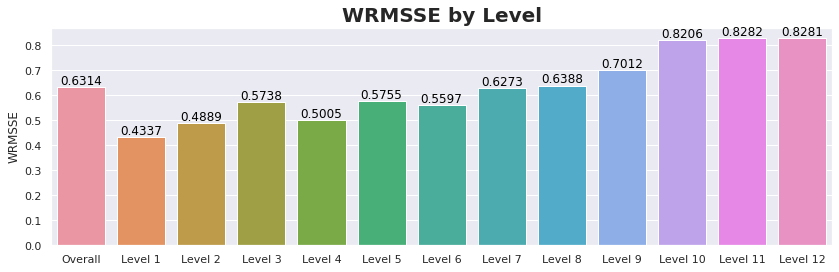

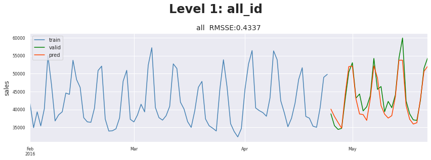

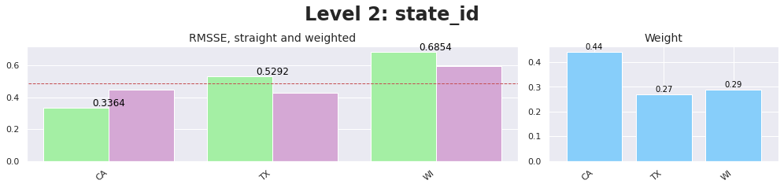

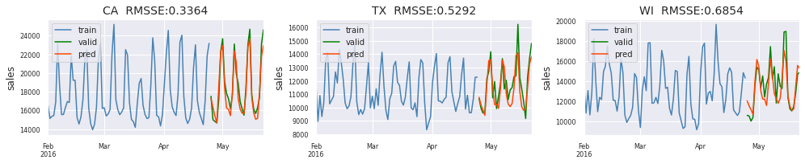

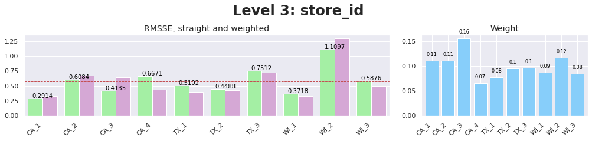

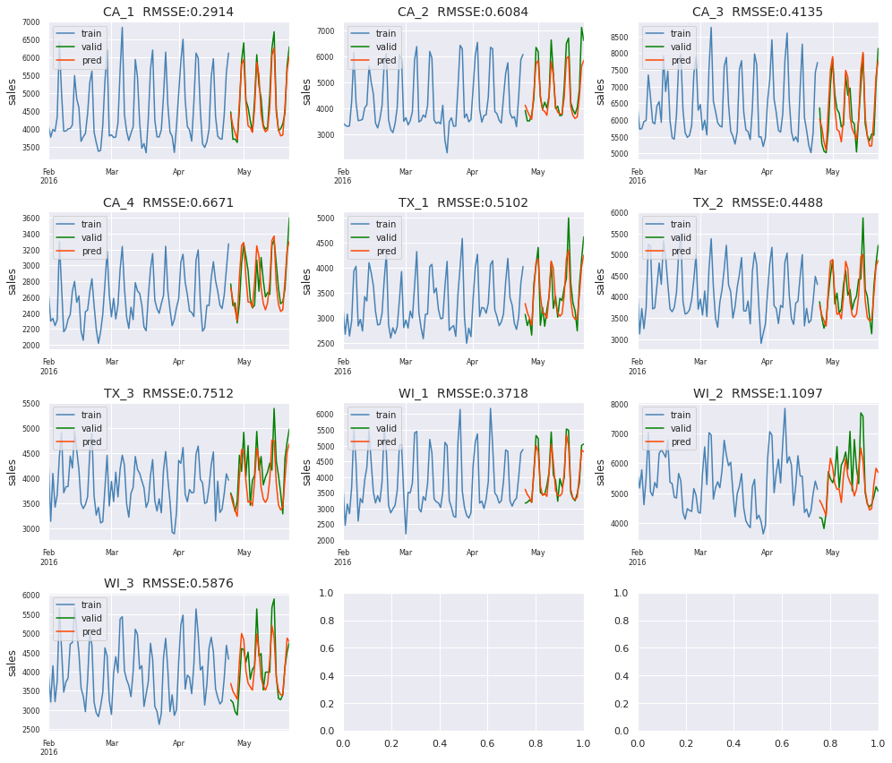

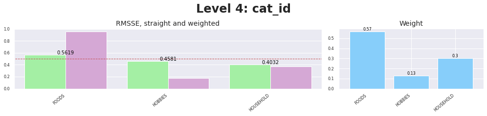

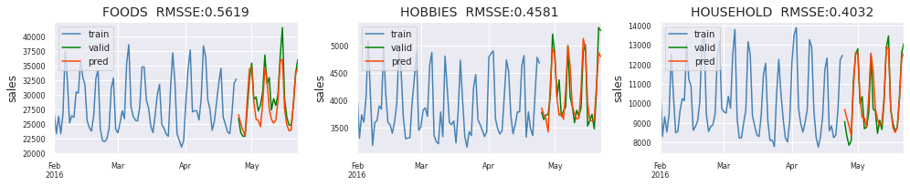

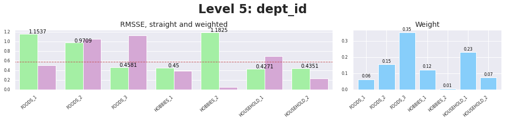

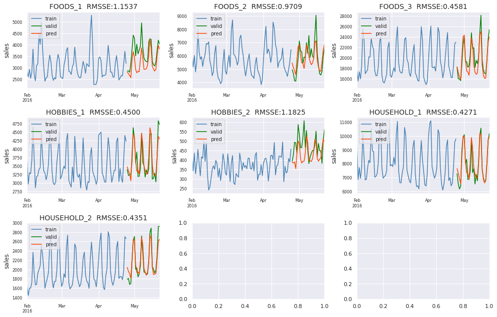

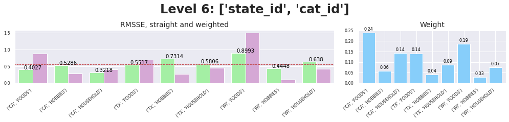

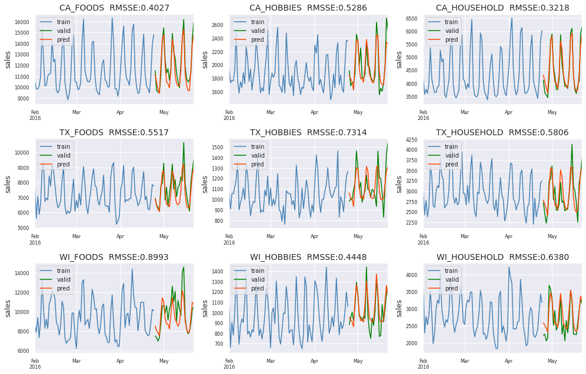

[8 more figures not shown]

```python
# Diagnose the model by investigating some of the predictions.
sales_clean = pd.read_csv("../input/m5-forecasting-accuracy/" + 'sales_train_evaluation.csv')
cal = pd.read_csv("../input/m5-forecasting-accuracy/calendar.csv")
prices = pd.read_csv("../input/m5-forecasting-accuracy/sell_prices.csv")
train_df = sales_clean.iloc[:, :-28]

valid_df = sales_clean.iloc[:, -28:] # forecast for the last 28 days of train period
evaluator = w.WRMSSEEvaluator(train_df, valid_df, cal, prices)

df_val_pred.columns = ["d_"+ str(i) for i in range(1914,1942)]

# Calculate validation scores
evaluator.score(df_val_pred)
evaluator.print_more_scores()

# Thanks kaggle comunity for providing visualisation code
w.create_dashboard(evaluator, groups='all', cal=cal)
```